# SOD1

Fold-switch pair **2namA_1uxmK** — **2namA** vs **1uxmK**

Homo sapiens

## Figure 1: Phylogenetic tree with per-cluster fold-preference heatmap.

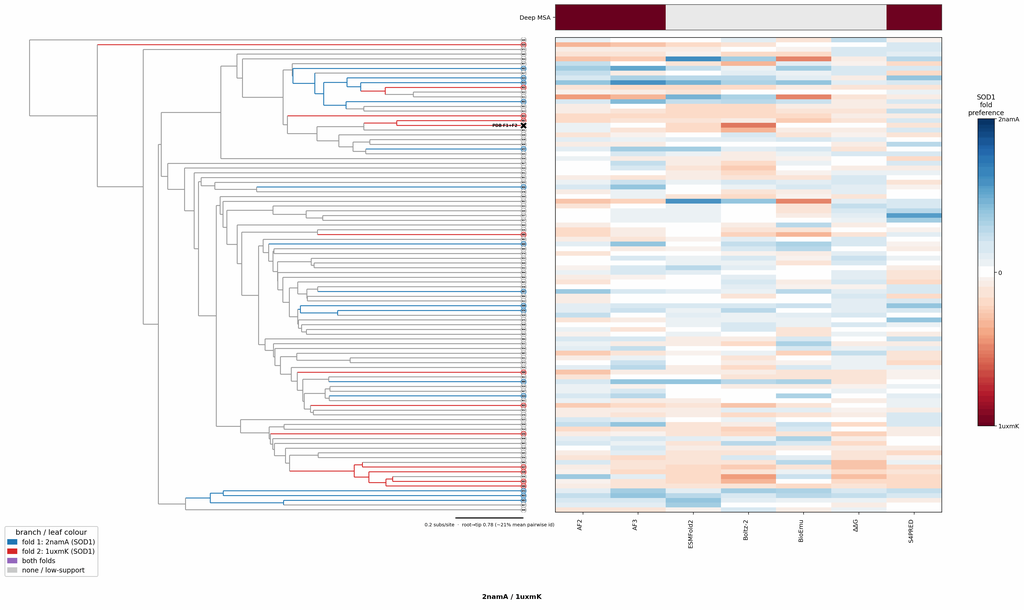

## Figure 2: Aligned overlay (both folds superposed)

The single fold-switching chain of each fold superposed by TM-align; waters hidden, any ligand shown as green sticks. Grey = structurally conserved core, colour = divergent (fold-switching) region. This pair switches fold coupled to oligomerisation; a single protomer is shown, not the full assembly.

2namA (SOD1) · monomer1uxmK (SOD1) · 12-mer

TM-score: 0.185 · Trigger class: oligomerization

Aligned overlay

## Figure 3: The two folds, side by side

Each fold is coloured by per-residue Cα deviation between the two superposed structures: grey ≈ conserved core, full colour = structurally divergent (fold-switching) region.

2namA (SOD1)

1uxmK (SOD1)

0 Å5≥10 Å

2namA (SOD1)

1uxmK (SOD1)

## Figure 4: Best-cluster predicted contact maps over the two true folds.

Predicted contact maps (MSA-Transformer) for the clusters best matching each fold, over the true contacts of fold 1 (upper triangle) and fold 2 (lower). Divergent contacts between clusters are the contact-level signature of fold-switching.

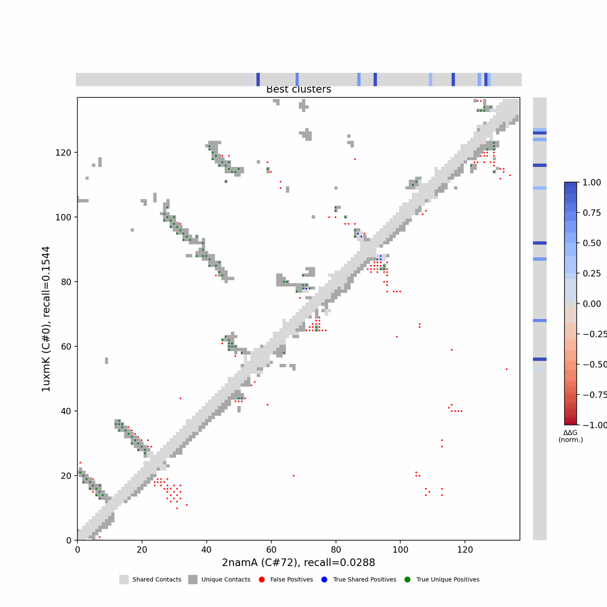

## Figure 5: Per-residue ΔΔG fold-preference contribution

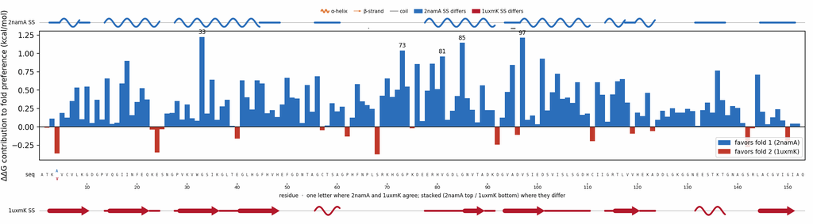

**More figures**

## Figure 6: Deep-MSA contact map panel / Best clusters contact map panel

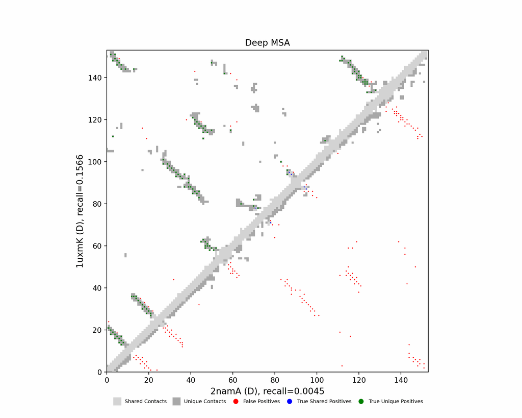

Deep-MSA contact map panel

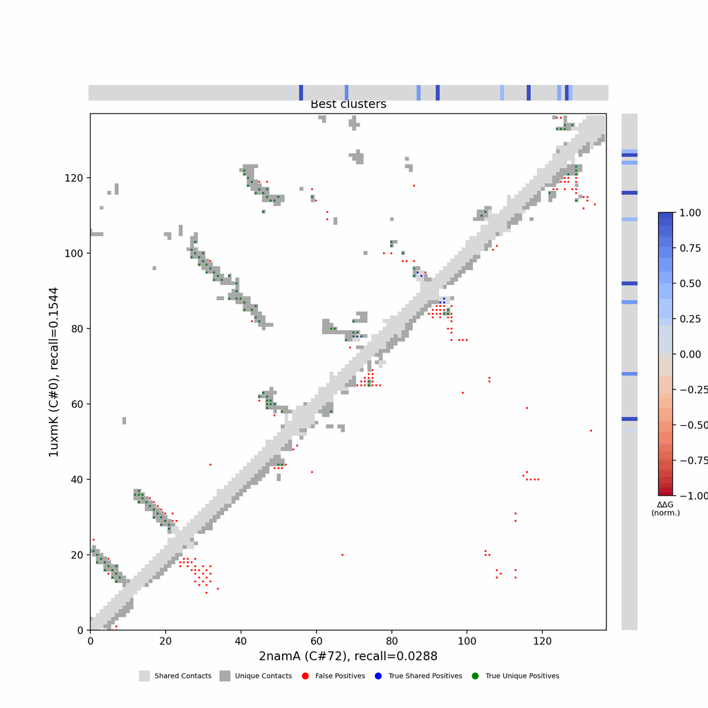

Best clusters contact map panel

## Figure 7: All clusters contact-map mosaic (small multiples).

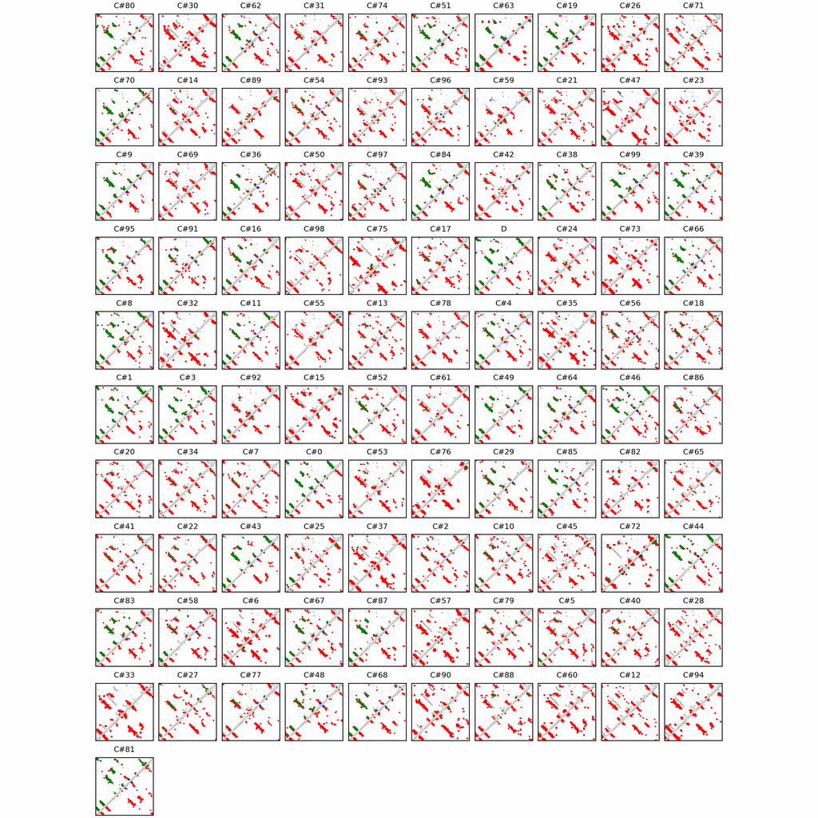

## Figure 8: Phylo null: tree with shuffled cluster fold labels.

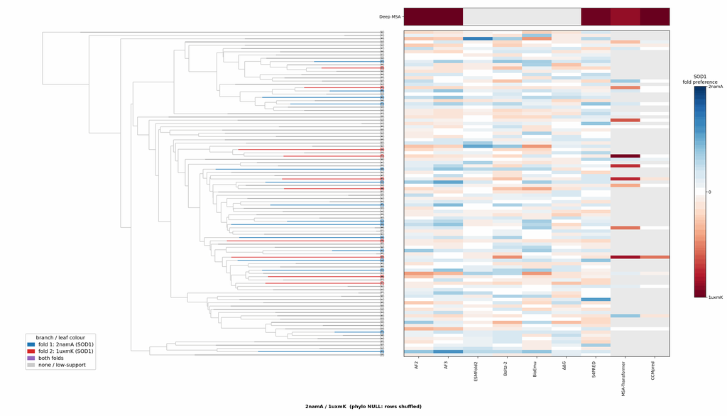

## Cluster metrics table

Per-cluster metrics underlying the figures above.

| cluster | n | neff | AF2_TM1 | AF2_TM2 | AF3_TM1 | AF3_TM2 | RE-MSAT-COM | RE-MSAT1 | RE-MSAT2 | ESM_SEQIDS | ESM_TM1 | ESM_TM2 | ΔΔG_Bias | ΔΔG_Bias_std | ΔΔG_frac_F1 | Boltz2_pref | S4PRED_pref | CCMpred_pref | BioEmu_pref |
| --- | --- | --- | --- | --- | --- | --- | --- | --- | --- | --- | --- | --- | --- | --- | --- | --- | --- | --- | --- |
| Deep | - | - | 0.17 | 0.99 | 0.18 | 0.99 | 0.03 | 0.02 | 0.49 | - | - | - | - | - | - | - | -0.38 | -0.22 | - |
| 000 | 1817.0 | 1125.0 | 0.16 | 0.52 | 0.2 | 0.77 | 0.03 | 0.03 | 0.44 | 008; 008; 009; 009; 001; 006; 005; 003; 001; 006 | 0.19 ± 0.01 | 0.78 ± 0.18 | 43.73 | 20.39 | 0.9 | -0.76 | -0.36 | -0.12 | -0.29 |
| 001 | 1067.0 | 758.0 | 0.19 | 0.56 | 0.18 | 0.85 | 0.03 | 0.03 | 0.47 | 001; 003; 003; 006; 006; 004; 005; 008; 008; 005 | 0.17 ± 0.00 | 0.79 ± 0.14 | 39.06 | 21.0 | 1.0 | -0.62 | -0.24 | -0.02 | -0.34 |
| 002 | 787.0 | 492.0 | 0.18 | 0.69 | 0.18 | 0.91 | 0.01 | 0.02 | 0.05 | 002; 002; 001; 004; 003; 001; 004; 003; 007; 007 | 0.17 ± 0.01 | 0.82 ± 0.04 | 36.31 | 19.23 | 1.0 | -0.49 | -0.36 | -0.02 | -0.34 |
| 003 | 782.0 | 577.0 | 0.17 | 0.76 | 0.18 | 0.9 | 0.03 | 0.02 | 0.47 | 006; 001; 006; 001; 002; 002; 005; 007; 005; 007 | 0.18 ± 0.01 | 0.80 ± 0.06 | 40.04 | 14.49 | 1.0 | -0.52 | -0.34 | -0.0 | -0.4 |
| 004 | 626.0 | 460.0 | 0.19 | 0.55 | 0.15 | 0.79 | 0.03 | 0.04 | 0.24 | 010; 010; 001; 001; 005; 009; 005; 004; 004; 009 | 0.19 ± 0.01 | 0.83 ± 0.03 | 46.03 | 15.84 | 1.0 | -0.23 | -0.31 | 0.0 | -0.38 |
| 005 | 553.0 | 396.0 | 0.18 | 0.8 | 0.17 | 0.87 | 0.0 | 0.02 | 0.03 | 003; 003; 001; 002; 009; 007; 005; 002; 001; 009 | 0.17 ± 0.01 | 0.77 ± 0.16 | 42.22 | 16.69 | 1.0 | -0.56 | -0.29 | -0.01 | -0.35 |
| 006 | 516.0 | 361.0 | 0.18 | 0.47 | 0.19 | 0.43 | 0.0 | 0.02 | 0.0 | 002; 003; 003; 005; 008; 007; 008; 007; 005; 001 | 0.17 ± 0.00 | 0.72 ± 0.13 | 49.62 | 14.32 | 1.0 | -0.32 | -0.32 | -0.0 | -0.19 |
| 007 | 502.0 | 411.0 | 0.19 | 0.41 | 0.18 | 0.74 | 0.01 | 0.01 | 0.07 | 006; 002; 006; 005; 002; 009; 004; 005; 009; 001 | 0.17 ± 0.01 | 0.75 ± 0.17 | 41.7 | 17.24 | 1.0 | -0.62 | -0.39 | 0.0 | -0.23 |
| 008 | 491.0 | 339.0 | 0.17 | 0.5 | 0.17 | 0.62 | 0.02 | 0.02 | 0.43 | 003; 003; 006; 006; 001; 009; 009; 001; 005; 002 | 0.18 ± 0.02 | 0.59 ± 0.33 | 39.38 | 15.5 | 1.0 | -0.31 | -0.3 | 0.0 | -0.11 |
| 009 | 450.0 | 363.0 | 0.18 | 0.65 | 0.17 | 0.77 | 0.05 | 0.04 | 0.38 | 007; 002; 001; 010; 004; 003; 002; 001; 004; 003 | 0.17 ± 0.00 | 0.82 ± 0.06 | 40.35 | 16.16 | 1.0 | -0.38 | -0.2 | 0.01 | -0.31 |
| 010 | 449.0 | 328.0 | 0.2 | 0.64 | 0.2 | 0.63 | 0.01 | 0.02 | 0.08 | 001; 002; 002; 001; 005; 006; 009; 006; 009; 007 | 0.17 ± 0.01 | 0.79 ± 0.06 | 40.37 | 15.13 | 1.0 | -0.55 | -0.34 | 0.01 | -0.3 |
| 011 | 436.0 | 276.0 | 0.17 | 0.93 | 0.17 | 0.99 | 0.03 | 0.03 | 0.31 | 007; 007; 002; 004; 008; 002; 001; 008; 003; 001 | 0.18 ± 0.01 | 0.82 ± 0.04 | 38.35 | 20.99 | 1.0 | -0.12 | -0.33 | -0.01 | -0.59 |
| 012 | 432.0 | 314.0 | 0.16 | 0.65 | 0.17 | 0.74 | 0.0 | 0.02 | 0.0 | 004; 004; 005; 009; 005; 009; 006; 002; 002; 001 | 0.17 ± 0.01 | 0.78 ± 0.10 | 49.78 | 10.5 | 1.0 | -0.33 | -0.25 | -0.0 | -0.29 |
| 013 | 380.0 | 238.0 | 0.2 | 0.68 | 0.18 | 0.84 | 0.01 | 0.03 | 0.03 | 006; 006; 002; 008; 004; 007; 001; 007; 004; 003 | 0.18 ± 0.01 | 0.74 ± 0.13 | 37.53 | 19.36 | 1.0 | -0.52 | -0.21 | -0.0 | -0.36 |
| 014 | 320.0 | 182.0 | 0.18 | 0.75 | 0.18 | 0.87 | 0.0 | 0.0 | 0.01 | 010; 005; 005; 010; 006; 002; 009; 006; 003; 002 | 0.18 ± 0.01 | 0.81 ± 0.05 | 42.39 | 14.15 | 1.0 | -0.53 | -0.33 | -0.0 | -0.21 |
| 015 | 313.0 | 223.0 | 0.17 | 0.47 | 0.15 | 0.45 | 0.0 | 0.02 | 0.01 | 002; 001; 008; 005; 003; 002; 001; 005; 003; 009 | 0.17 ± 0.00 | 0.70 ± 0.07 | 40.19 | 20.85 | 0.9 | -0.16 | -0.15 | -0.0 | -0.23 |
| 016 | 280.0 | 208.0 | 0.21 | 0.54 | 0.16 | 0.49 | 0.03 | 0.05 | 0.21 | 001; 002; 005; 003; 002; 001; 005; 010; 003; 010 | 0.19 ± 0.00 | 0.85 ± 0.08 | 46.28 | 8.44 | 1.0 | -0.5 | -0.28 | 0.0 | -0.21 |
| 017 | 274.0 | 221.0 | 0.18 | 0.4 | 0.15 | 0.75 | 0.01 | 0.04 | 0.05 | 003; 007; 003; 007; 004; 004; 008; 006; 008; 006 | 0.18 ± 0.01 | 0.72 ± 0.15 | 50.77 | 14.37 | 1.0 | -0.3 | -0.37 | 0.0 | -0.25 |
| 018 | 271.0 | 195.0 | 0.17 | 0.58 | 0.16 | 0.57 | 0.0 | 0.02 | 0.06 | 002; 002; 001; 010; 006; 001; 006; 010; 009; 004 | 0.17 ± 0.01 | 0.77 ± 0.13 | 39.65 | 16.25 | 1.0 | -0.41 | -0.33 | 0.0 | -0.33 |
| 019 | 253.0 | 149.0 | 0.16 | 0.52 | 0.16 | 0.76 | 0.05 | 0.04 | 0.33 | 001; 010; 003; 002; 002; 001; 003; 010; 008; 009 | 0.18 ± 0.01 | 0.78 ± 0.22 | 41.71 | 9.67 | 1.0 | -0.41 | -0.28 | 0.0 | -0.33 |
| 020 | 248.0 | 181.0 | 0.16 | 0.84 | 0.17 | 0.96 | 0.0 | 0.02 | 0.02 | 004; 004; 001; 009; 009; 008; 002; 002; 001; 008 | 0.18 ± 0.02 | 0.80 ± 0.08 | 44.34 | 15.51 | 1.0 | -0.48 | -0.25 | 0.0 | -0.3 |
| 021 | 247.0 | 177.0 | 0.18 | 0.54 | 0.16 | 0.79 | 0.0 | 0.01 | 0.01 | - | - | - | 40.47 | 11.39 | 1.0 | -0.5 | -0.34 | - | -0.11 |
| 022 | 242.0 | 175.0 | 0.18 | 0.63 | 0.16 | 0.77 | 0.01 | 0.02 | 0.07 | - | - | - | 42.12 | 19.46 | 1.0 | -0.33 | -0.29 | - | -0.27 |
| 023 | 223.0 | 154.0 | 0.15 | 0.25 | 0.18 | 0.24 | 0.0 | 0.0 | 0.0 | - | - | - | 49.79 | 10.69 | 1.0 | -0.11 | -0.23 | - | -0.07 |
| 024 | 214.0 | 130.0 | 0.16 | 0.47 | 0.16 | 0.5 | 0.0 | 0.02 | 0.0 | - | - | - | 42.13 | 12.26 | 1.0 | -0.34 | -0.27 | - | -0.12 |
| 025 | 210.0 | 95.0 | 0.19 | 0.47 | 0.16 | 0.66 | 0.0 | 0.02 | 0.06 | - | - | - | 43.85 | 8.83 | 1.0 | -0.32 | -0.25 | - | -0.28 |
| 026 | 202.0 | 149.0 | 0.15 | 0.73 | 0.14 | 0.78 | 0.0 | 0.0 | 0.01 | - | - | - | 42.23 | 9.56 | 1.0 | -0.47 | -0.32 | - | -0.37 |
| 027 | 202.0 | 84.0 | 0.19 | 0.68 | 0.16 | 0.84 | 0.0 | 0.02 | 0.05 | - | - | - | 26.93 | 15.02 | 1.0 | -0.55 | -0.38 | - | -0.37 |
| 028 | 201.0 | 140.0 | 0.14 | 0.49 | 0.14 | 0.66 | 0.0 | 0.0 | 0.0 | - | - | - | 50.06 | 13.54 | 1.0 | -0.27 | -0.31 | - | -0.18 |

[output cut: 71 more lines]